# Problem Set 9

Due date: 4 December

**Kennedy Lighty**

```r
library(tidyverse)
library(wbstats)
library(broom)
library(modelsummary)
library(marginaleffects)
library(plotly)
library(ggdist)
library(stargazer)
library(dplyr)
```

Please upload your completed assignment to the ELMs course site (under the assignments menu). Remember to include an annotated script file for all work with R and show your math for all other problems (if applicable, or necessary). Please also upload your completed assignment to the Github repository that you have shared with us. *We should be able to run your script with no errors.*

**Total points: 40**

## Question 1

*Points: 10*

**Note**

10/10

Table 1 below reports the results from two regression models. In Model 1 in Table 1 $Y$ is regressed on $X_1$ and, in Model 2, $Y$ is regressed on both $X_1$ and $X_2$. Why might $X_1$ be statistically significant at conventional levels in Model 1 but statistically insignificant in Model 2? Be as specific as possible.

**There is a difference in the model due to omitted variable bias. The coefficient of 𝑋1 could have been capturing both its direct influence on 𝑌 and the effect of 𝑋2, which is associated with 𝑋 1 and 𝑌, therefore X2 is omitted.**

## Question 2

*Points: 10*

**Note**

7/10

Using the `censusAggregate` dataset (posted on ELMs), which is survey data aggregated to the state level (1972-2000), estimate a regression with `vote` as the dependent variable and the following independent variables: `nonSouth`, `edr`, and `pcthsg`. Report the results in a professionally formatted table and interpret the regression results.

Also, create a figure to display the predicted values (with confidence intervals) for the effect of `pcthsg` on the turnout rate. Lastly, is it meaningful to interpret the constant term on its own? Why, or why not?

**Note**

`vote` is the turnout rate in a state in a given year (i.e., the number of people who voted divided by the number eligible to vote).

`nonSouth` is a dummy variable equal to `0` for Southern states and a `1` for non-Southern states.

`pcthsg` is the percentage of the population in a state that graduated high school.

`edr` is a dummy variable equal to `1` for states that used election-day registration and a `0` for states without election-day registration.

```r
censusAggregate <- read.csv("censusAggregate.csv")
model <- lm(vote ~ nonSouth + edr + pcthsg, data = censusAggregate)

stargazer(model, type = "text",
          title = "Regression Results: Predicting Vote Turnout",
          dep.var.labels = "Turnout Rate (vote)",
          covariate.labels = c("Non-Southern States (nonSouth)",
                               "Election Day Registration (edr)",
                               "Percent High School Graduates (pcthsg)"),
          omit.stat = c("f", "ser"),
          notes = "* p < 0.05, ** p < 0.01, *** p < 0.001")
```

```
Regression Results: Predicting Vote Turnout
=============================================================================
                                                Dependent variable:
                                       --------------------------------------
                                                Turnout Rate (vote)
-----------------------------------------------------------------------------
Non-Southern States (nonSouth)                        5.546***
                                                      (0.797)

Election Day Registration (edr)                       5.792***
                                                      (1.056)

Percent High School Graduates (pcthsg)                0.101***
                                                      (0.036)

Constant                                             54.002***
                                                      (2.616)

-----------------------------------------------------------------------------
Observations                                            357
R2                                                     0.281
Adjusted R2                                            0.275
=============================================================================
Note:                                             *p<0.1; **p<0.05; ***p<0.01
                                       * p < 0.05, ** p < 0.01, *** p < 0.001
```

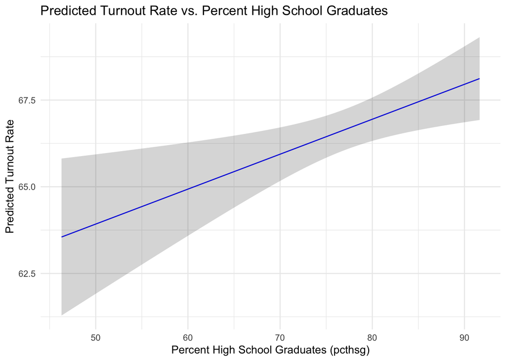

```r
new_data <- data.frame(
  nonSouth = mean(censusAggregate$nonSouth, na.rm = TRUE),
  edr = mean(censusAggregate$edr, na.rm = TRUE),
  pcthsg = seq(min(censusAggregate$pcthsg), max(censusAggregate$pcthsg), length.out = 100)
)

predictions <- predict(model, newdata = new_data, interval = "confidence")
new_data$predicted <- predictions[, "fit"]
new_data$lwr <- predictions[, "lwr"]
new_data$upr <- predictions[, "upr"]

ggplot(new_data, aes(x = pcthsg, y = predicted)) +
  geom_line(color = "blue") +
  geom_ribbon(aes(ymin = lwr, ymax = upr), alpha = 0.2) +
  labs(title = "Predicted Turnout Rate vs. Percent High School Graduates",
       x = "Percent High School Graduates (pcthsg)",
       y = "Predicted Turnout Rate") +
  theme_minimal()
```

**Note**

Don’t worry about including the coded variable names in your plots or tables (for example, `nonSouth`). Your reader doesn’t need to know this.

**The regression indicates that there is a difference between voters in southern states versus in non-southern states. Showing that non-southern states have higher percentages of voter turnout rate.**

**Note**

… on average and holding all else constant. Also, please tell me by how much (5.5%).

**The data also shows that states with election day registration have higher percents of voter turnout as well.**

**Note**

See above.

**Voter turnout increases by 0.10 percentage points for every percentage point rise in high school graduation rates.**

**Note**

… on average and holding all else constant.

**Interpreting the constant is not meaningful because it is a baseline reference point and is not relevant to the question.**

**Note**

Why? Because there is not and never will be a state with a 0% high school graduation rate.

## Question 3

*Points: 5*

**Note**

5/5

Using the regression results from the previous question, evaluate the null hypothesis that the effects (i.e., regression coefficients) of `nonSouth` and `pcthsg` are jointly equal to zero. Can you reject the null hypothesis? Be sure to demonstrate how you reached a definitive conclusion.

```r
unrestricted_model <- lm(vote ~ nonSouth + edr + pcthsg, data = censusAggregate)
restricted_model <- lm(vote ~ edr, data = censusAggregate)
f_test <- anova(restricted_model, unrestricted_model)
print(f_test)
```

```
Analysis of Variance Table

Model 1: vote ~ edr
Model 2: vote ~ nonSouth + edr + pcthsg
  Res.Df   RSS Df Sum of Sq      F    Pr(>F)
1    355 13919
2    353 11277  2    2641.8 41.347 < 2.2e-16 ***
---
Signif. codes:  0 '***' 0.001 '**' 0.01 '*' 0.05 '.' 0.1 ' ' 1
```

**The null hypothesis is that the coefficients of nonSouth and pcthsg are both zero. Therefore, we can reject the null hypothesis.**

## Question 4

*Points: 15*

**Note**

10/15

Using one of the other data sets available in the `poliscidata` package pick one dependent variable and two or more independent variables. Run a regression of the dependent variable on the independent variables. In your answer, describe why you picked the variables you did, produce a professionally formatted results table, and describe your statistical and substantive findings.

```r
library(poliscidata)
data("nes")
nes_filtered <- nes %>%
    filter(!is.na(obama_therm), !is.na(dem_age_group_r), !is.na(conservatism))

model <- lm(obama_therm ~ dem_age_group_r + conservatism, data = nes_filtered)

summary(model)
```

```
Call:
lm(formula = obama_therm ~ dem_age_group_r + conservatism, data = nes_filtered)

Residuals:
    Min      1Q  Median      3Q     Max
-97.475 -16.417  -0.906  19.271  91.380

Coefficients:
                         Estimate Std. Error t value Pr(>|t|)
(Intercept)             66.357733   2.114808  31.378  < 2e-16 ***
dem_age_group_r21-24    -1.164530   2.637578  -0.442  0.65886
dem_age_group_r25-29    -5.656614   2.520107  -2.245  0.02484 *
dem_age_group_r30-34    -3.886312   2.486771  -1.563  0.11816
dem_age_group_r36-39    -3.474014   2.524254  -1.376  0.16880
dem_age_group_r40-44    -4.166822   2.452331  -1.699  0.08935 .
dem_age_group_r45-49    -1.780535   2.467284  -0.722  0.47054
dem_age_group_r50-54    -1.268526   2.384608  -0.532  0.59477
dem_age_group_r55-59    -2.856843   2.365659  -1.208  0.22724
dem_age_group_r60-64    -4.010994   2.402705  -1.669  0.09510 .
dem_age_group_r65-69    -3.239468   2.429318  -1.333  0.18243
dem_age_group_r70-74    -8.014572   2.602279  -3.080  0.00208 **
dem_age_group_r75-older -4.677475   2.587736  -1.808  0.07073 .
conservatism            -0.538517   0.008687 -61.992  < 2e-16 ***
---
Signif. codes:  0 '***' 0.001 '**' 0.01 '*' 0.05 '.' 0.1 ' ' 1

Residual standard error: 26.33 on 5273 degrees of freedom
Multiple R-squared:  0.4281,    Adjusted R-squared:  0.4267
F-statistic: 303.7 on 13 and 5273 DF,  p-value: < 2.2e-16
```

```r
modelsummary(model,
             title = "Regression Results: Predictors of Obama Favorability",
             coef_map = c("dem_age_group_r" = "Age Group (dem_age_group_r)",
                          "conservatism" = "Conservatism"),
             gof_omit = "Adj|AIC|BIC")
```

Regression Results: Predictors of Obama Favorability

|  | (1) |
| --- | --- |
| Conservatism | −0.539 |
|  | (0.009) |
| Num.Obs. | 5287 |
| R2 | 0.428 |
| Log.Lik. | −24786.882 |
| F | 303.687 |
| RMSE | 26.29 |

**Note**

Your table is missing the age variables. This is because your age variable is a multiple categorical variable. It has 13 groups (based on respondents’ ages). Look at what prints out when you ran `summary(model)`.

We haven’t covered this directly yet, but the model therefore holds one group out to act as a baseline. Here, it has held the youngest age group out as that baseline group. This baseline group gets folded into the intercept. So, the intercept is the predicted feeling rating for individuals *aged 17-20 years old* who are centerist (have a conservatism score of zero), on average.

The coefficient for each other age group is the additional feeling rating with relation to that baseline age group. So, your model predicts that individuals aged 21 to 24 rate Obama 1.16 points lower than individuals aged 17-20, on average and holding all else constant.

**Note**

Your coefficient estimates are always the average estimate for these groups. And you need to remember to say that you are holding all else constant.

**Note**

Missing a discussion of whether these are statistically and substantively significant.